# Snowball Search and global quantification of the references

# Setup

```r
#|

# library(bibtex)
library(openalexR)
library(writexl)
library(tibble)
library(dplyr)
library(ggplot2)
library(ggraph)
library(tidygraph)
library(knitr)

list.files(
    "R",
    full.names = TRUE,
    recursive = TRUE
) |>
    sapply(
        FUN <- source
    )
```

```
        R/plot_snowball.R R/to_xlsx.R
value   ?                 ?
visible FALSE             FALSE
```

```r
kp <- read.csv("./key_papers.csv")
kp <- split(kp, kp$ro)
```

# Searches

## OpenAlex

### Setup OpelAnex usage and do snowball serarch

```r
#|

key_works <- lapply(
    kp,
    function(x) {
        oa_fetch(
            entity = "works",
            doi = x$doi,
            verbose = FALSE
        )
    }
)

saveRDS(key_works, "key_works.rds")

ids <- lapply(
    key_works,
    function(x){
        openalexR:::shorten_oaid(x$id)
    }
)

fn <- file.path(".", "data", "snowball.rds")
if (file.exists(fn)) {
    snowball <- readRDS(fn)
} else {
    snowball <- lapply(
        ids,
        function(x) {
            oa_snowball(
                identifier = x,
                verbose = FALSE
            )
        }
    )
    saveRDS(snowball, fn)
}

flat_snow <- lapply(
    snowball,
    function(x){
        snowball2df(x) |>
        as_tibble()
    }
)
```

```r
#|

###

lapply(
    names(snowball),
    function(x) {
        fn <- file.path(".", "data", paste0(x, ".xlsx"))
        to_xlsx(
            snowball = snowball[[x]],
            flat_snow = flat_snow[[x]],
            xls_filename = fn
        )
    }
)
```

```
[[1]]
[1] "/Users/rainerkrug/Documents_Local/git/IPBES_data_tsu/Assessments/Transformative Change/IPBES_TFC_Ch5/data/ agriculture.xlsx"

[[2]]
[1] "/Users/rainerkrug/Documents_Local/git/IPBES_data_tsu/Assessments/Transformative Change/IPBES_TFC_Ch5/data/ dams.xlsx"

[[3]]
[1] "/Users/rainerkrug/Documents_Local/git/IPBES_data_tsu/Assessments/Transformative Change/IPBES_TFC_Ch5/data/ fertilizer.xlsx"
```

The column are: (the Concept columns are not that relevant at the moment)

- **id**: internal id fromOpenAlex
- **author**: authors of the paper
- **publication_year**: publication year
- **title**: title of the paper
- **doi**: doi of the paper
- **no_referenced_works**: number of references in the paper which are also in OpenAlex
- **cited_global**: Number of times the paper has been cited
- **cited_global_per_year**: standardised number of times cirted (cited_global / number of years published)
- **no_connections**: number of connections in the rgaph, i.e. either cited or citing a paper in the snowball corpus
- **concepts_l0**: Concept 0. level assigned by OpenAlex
- **concepts_l1**: Concept 1. level assigned by OpenAlex
- **concepts_l2**: Concept 2. level assigned by OpenAlex
- **concepts_l3**: Concept 3. level assigned by OpenAlex
- **concepts_l4**: Concept 4. level assigned by OpenAlex
- **concepts_l5**: Concept 5. level assigned by OpenAlex
- **author_institute**: Institute of the authors
- **institute_country**: Country of the institute
- **abstract**: the abstract of the paper

### Graph of links between references

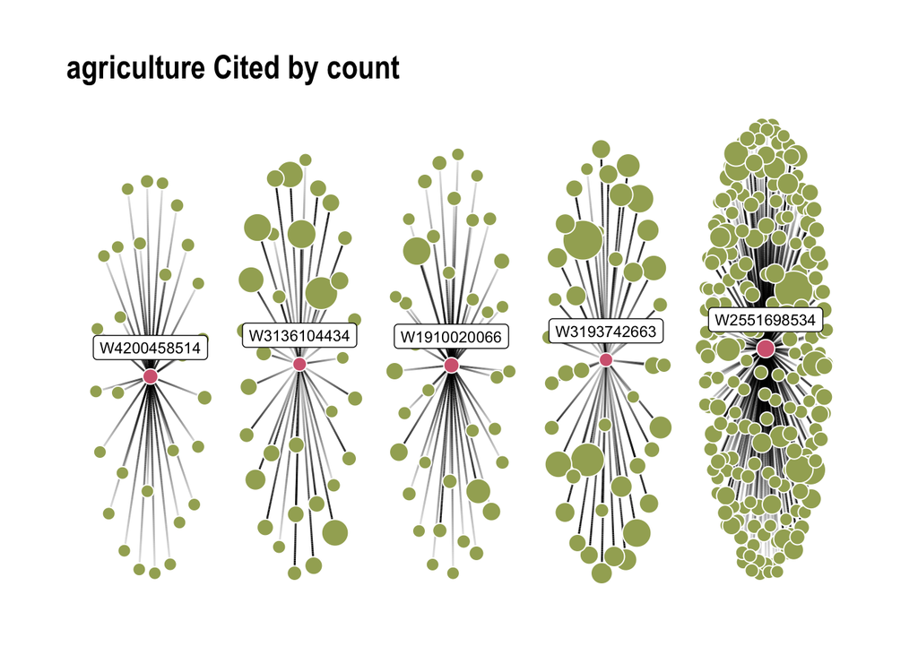

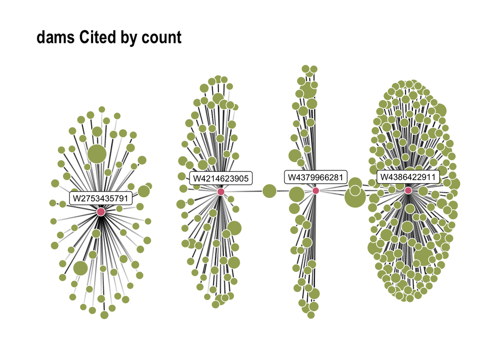

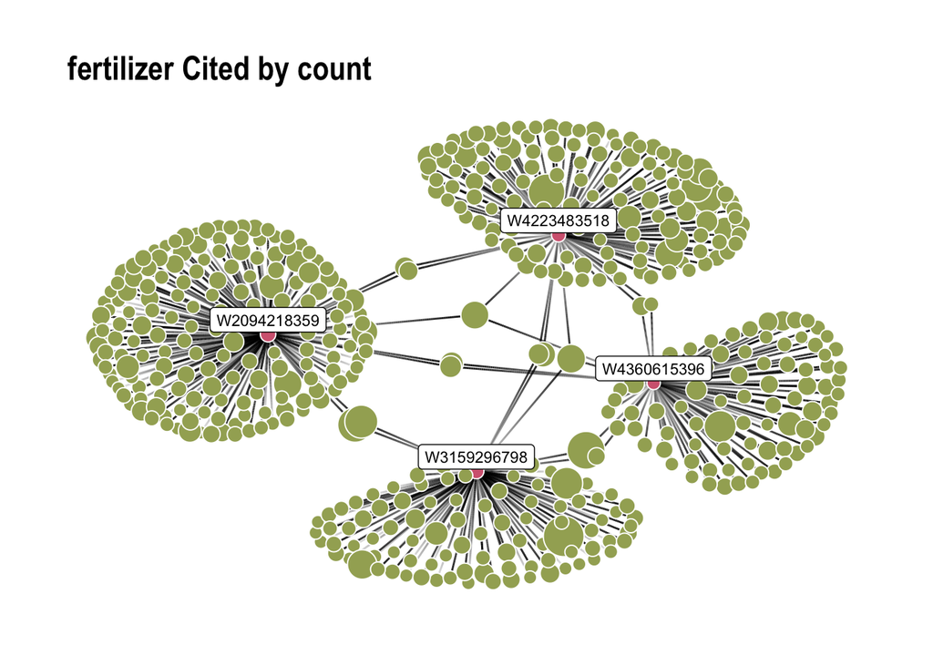

```r
#|

lapply(
    names(snowball),
    function(x){
        plot_snowball(
            snowball[[x]],
            name = x
        )
    }
)
```

### Identification of references with more than one edge

This is the number of connections (`connection_count)`of the paper (`id`)

```r
#|

mult_edge <- lapply(
    flat_snow,
    function(flat_snow) {
        mult_edge <- flat_snow |>
            select(id, connection_count) |>
            filter(connection_count > 1) |>
            arrange(desc(connection_count))
    }
)

links <- lapply(
    names(flat_snow),
    function(x) {
        flat_snow[[x]] |>
            filter(id %in% mult_edge[[x]]$id)
    }
)

lapply(
    links,
    function(links) {
        links |>
            select(id, display_name, publication_year, doi, connection_count) |>
            arrange(desc(connection_count)) |>
            knitr::kable()
    }
)
```

```
[[1]]


|id          |display_name                                                                                                        | publication_year|doi                                      | connection_count|
|:-----------|:-------------------------------------------------------------------------------------------------------------------|----------------:|:----------------------------------------|----------------:|
|W2551698534 |Drought Tolerance and Water Use of Cereal Crops: A Focus on Sorghum as a Food Security Crop in Sub-Saharan Africa   |             2016|https://doi.org/10.1111/jac.12191        |              207|
|W3193742663 |Adaptive Crop Management under Climate Uncertainty: Changing the Game for Sustainable Water Use                     |             2021|https://doi.org/10.3390/atmos12081080    |               44|
|W1910020066 |ADVANCES AND CHALLENGES WITH MICRO-IRRIGATION                                                                       |             2013|https://doi.org/10.1002/ird.1704         |               38|
|W3136104434 |Sustainable alternative futures for agriculture in India—the energy, emissions, and resource implications           |             2021|https://doi.org/10.1088/1748-9326/abf0cd |               33|
|W4200458514 |The State of the World’s Land and Water Resources for Food and Agriculture – Systems at breaking point (SOLAW 2021) |             2021|https://doi.org/10.4060/cb7654en         |               29|

[[2]]


|id          |display_name                                                                                                                                                                                                        | publication_year|doi                                              | conn…
|:-----------|:-------------------------------------------------------------------------------------------------------------------------------------------------------------------------------------------------------------------|----------------:|:------------------------------------------------|-----…
|W4386422911 |A metasystem approach to designing environmental flows                                                                                                                                                              |             2023|https://doi.org/10.1093/biosci/biad067           |     …
|W4214623905 |Do dams improve water security in India? A review of post facto assessments                                                                                                                                         |             2022|https://doi.org/10.1016/j.wasec.2022.100112      |     …
|W2753435791 |Assessing the feasibility of integrating ecosystem-based with engineered water resource governance and management for water security in semi-arid landscapes: A case study in the Banas catchment, Rajasthan, India |             2018|https://doi.org/10.1016/j.scitotenv.2017.08.308  |     …
|W4379966281 |Optimizing environmental flow based on a new optimization model in balancing objectives among river ecology, water supply and power generation in a high-latitude river                                             |             2023|https://doi.org/10.1016/j.jenvman.2023.118261    |     …
|W2096113236 |The Natural Flow Regime                                                                                                                                                                                             |             1997|https://doi.org/10.2307/1313099                  |     …
|W2151941169 |How much water does a river need?                                                                                                                                                                                   |             1997|https://doi.org/10.1046/j.1365-2427.1997.00153.x |     …
|W2156113027 |Environmental flows for natural, hybrid, and novel riverine ecosystems in a changing world                                                                                                                          |             2014|https://doi.org/10.1890/130134                   |     …
|W2156353061 |The ecological limits of hydrologic alteration (ELOHA): a new framework for developing regional environmental flow standards                                                                                        |             2010|https://doi.org/10.1111/j.1365-2427.2009.02204.x |     …

[[3]]


|id          |display_name                                                                                                                                             | publication_year|doi                                                             | connection_count|
|:-----------|:--------------------------------------------------------------------------------------------------------------------------------------------------------|----------------:|:---------------------------------------------------------------|----------------:|
|W2094218359 |Consequence of altered nitrogen cycles in the coupled human and ecological system under changing climate: The need for long-term and site-based research |             2014|https://doi.org/10.1007/s13280-014-0545-4                       |              177|
|W4223483518 |Nitrogenous fertilizers: impact on environment sustainability, mitigation strategies, and challenges                                                     |             2022|https://doi.org/10.1007/s13762-022-04027-9                      |              135|
```

[output cut: 17 more lines]

# Finalize

To convert to pdf run e.g.

```bash
    wkhtmltopdf snowball.html snowball.pdf
```